# Demo_Multisample_mCCC_analysis

## The mCCC analysis using scRNA-seq data from multiple conditions, including differential analysis.

#### Jump to the section #2 for differential analysis instructions

In this tutorial, we apply MEBOCOST on a demo dataset which 200 cells were sampled from a HNSC scRNA-seq data (GSE103322).

Note: since this demo was analyzed by simulated data, the predicted result of communication might looks not biologically meaningful. The goal of this notebook is to show the step-by-step analysis

```python
import os,sys
import scanpy as sc
import pandas as pd
import numpy as np
from matplotlib import pyplot as plt
import seaborn as sns
from mebocost import mebocost
```

## 1. Create mebocost object for running mCCC with multiple conditions in one run

Users can pass data either by adata scanpy object (1.1 reccomended), or by python pandas data frame (1.2)

### 1.1 get expression and cell annotation data from scanpy object

```python
adata = sc.read_h5ad('data/demo/raw_scRNA/demo_HNSC_200cell.h5ad')
## check adata (cells, genes)
print('# of cell: %s, # of gene: %s'%adata.shape)
print('Conditions: %s'%adata.obs['Site'].unique().tolist())

### make sure your adata cover all genes and all cells
### if not, you may want to load all genes saved in raw by doing:
# adata = adata.raw.copy()
```

```
# of cell: 200, # of gene: 18241
Conditions: ['Lymph node', 'Primary']
```

#### create mebocost object

**Please avoid using '~' in condition names, as it may cause error in running**

```python
## initiate the mebocost object
### import expression data by scanpy adata object
mebo_obj = mebocost.create_obj(
                        adata = adata,
                        ## "celltype" must be a column name of adata.obs table, otherwise, change it according to your data.
                        group_col = 'celltype',
                        ## "Site" must be a column name of adata.obs table, otherwise, change it according to your data.
                        condition_col = 'Site',
                        met_est = 'mebocost',
                        # make sure mebocost.conf file in the same folder of this notebook, otherwise, provide a absolute path.
                        config_path = './mebocost.conf',
                        exp_mat=None,
                        cell_ann=None,
                        ## make sure you set the right species
                        species='human',
                        met_pred=None,
                        met_enzyme=None,
                        met_sensor=None,
                        met_ann=None,
                        scFEA_ann=None,
                        compass_met_ann=None,
                        compass_rxn_ann=None,
                        cutoff_exp='auto', ## automated cutoff to exclude lowly ranked 25% sensors across all cells
                        cutoff_met='auto', ## automated cutoff to exclude lowly ranked 25% metabolites across all cells
                        cutoff_prop=0.15, ## at lease 10% of cells should be expressed the sensor or present the metabolite in the cell group (specified by group_col)
                        sensor_type='All',
                        thread=8
                        )
```

```
[July 24, 2025 13:27:43]: We get expression data with 18241 genes and 200 cells.
[July 24, 2025 13:27:43]: Data Preparation Done in 0.0866 seconds
```

### 1.2 get expression and cell annotation from external files (skip if you have done 1.1)

Users can provide exp_mat (scRNA-seq gene-by-cell expression matrix) and cell_ann (cell-by-annoatation matrix) from external files, such as .csv, .tsv, and .txt files, to MEBOCOST for mCCC analysis. Please refer to pandas read_csv functions to read those files ([read_csv](https://pandas.pydata.org/docs/reference/api/pandas.read_csv.html)) into Python. In the case that users want to use expression data and meta data from Seurat in R. It is strongly recommended first writing out expression matrix and meta data (cell annotation) from Seurat in R. Once the expression and meta data were saved in your local, those files can be read into Python by pandas and then pass to mebocost as the instructions in following. Please make sure you have total genes in the table, rather than only highly variable genes.

```python
### pass expression data and cell annotation table by pandas data frame
### taking exp_mat and cell_all from the above
### read expression data from a external file
exp_mat = pd.read_csv(your_exp_data_file)
cell_ann = pd.read_csv(your_cell_ann_data_file)

mebo_obj = mebocost.create_obj(
                        adata = None,
                        ## "Celltype" must be a column name of adata.obs table, otherwise, change it according to your data.
                        group_col = 'celltype',
                        ## "Site" must be a column name of adata.obs table, otherwise, change it according to your data.
                        condition_col = 'Site',
                        met_est = 'mebocost',
                        # make sure mebocost.conf file in the same folder of this notebook, otherwise, provide a absolute path.
                        config_path = './mebocost.conf',
                        exp_mat=exp_mat,
                        cell_ann=cell_ann,
                        ## make sure you set the right species
                        species='human',
                        met_pred=None,
                        met_enzyme=None,
                        met_sensor=None,
                        met_ann=None,
                        scFEA_ann=None,
                        compass_met_ann=None,
                        compass_rxn_ann=None,
                        cutoff_exp='auto', ## automated cutoff to exclude lowly ranked 25% sensors across all cells
                        cutoff_met='auto', ## automated cutoff to exclude lowly ranked 25% metabolites across all cells
                        cutoff_prop=0.15, ## at lease 10% of cells should be expressed the sensor or present the metabolite in the cell group (specified by group_col)
                        sensor_type='All',
                        thread=8
                        )
```

#### 1.3 Aggregating metabolite enzyme expression [Optional]

Note: this estimation have been already incoperated in mebo_obj.infer_commu, so only run this step separately if you just want to aggregate enzyme expression for metabolites and stop from doing further analysis.

```python
## 【optional】only aggregate metabolite enzyme expression for cells
## this estimation actually included in infer_commu function, if you want
## two steps include loading config and running estimator
mebo_obj._load_config_()
mebo_obj.estimator()
```

```
[July 23, 2025 23:09:14]: Load config and read data based on given species [human].
[July 23, 2025 23:09:14]: Estimtate metabolite enzyme expression using mebocost
```

```python
## check the aggregated enzyme expression for metabolites
met_mat = pd.DataFrame(mebo_obj.met_mat.toarray(),
                      index = mebo_obj.met_mat_indexer,
                      columns = mebo_obj.met_mat_columns)
## print head
met_mat.head()
```

|  | HNSCC5_p14_HNSCC5_P14_LN_H02 | HNSCC_17_P10_C11_S227_comb | HNSCC6_p15_HNSCC6_P15_LN_D05 | HNSCC25_P2_A10_S10_comb | HNSCC16_P4_HNSCC16_P4_B11 | HNSCC18_P7_F06_S162_comb | HNSCC25_P4_E04_S244_comb | HNSCC20_P5_pri_A01_S1_comb | HN28_P5_F10_S262_comb | HNSCC17_P13_E12_S348_comb | ... | HNSCC6_p16_HNSCC6_P16_B03 | HNSCC8_1ant_HNSCC8_1ant_A06 | HNSCC26_P24_H06_S378_comb | HNSCC16_P2_F09_S69_comb | HNSCC6_p14_hnscc6_p14_D12 | HNSCC18_P2_F02_S158_comb | HNSCC16_P12_HNSCC16_P12_G10 | HNSCC16_P14_HNSCC16_P14_H10 | HNSCC6_p16_HNSCC6_P16_E07 | HNSCC28_P13_A12_S204_comb |
| --- | --- | --- | --- | --- | --- | --- | --- | --- | --- | --- | --- | --- | --- | --- | --- | --- | --- | --- | --- | --- | --- |
| HMDB0003450 | 0.000000 | 0.000000 | 0.000000 | 0.000000 | 0.000000 | 0.000000 | 0.0 | 0.000000 | 0.000000 | 0.000000 | ... | 0.000000 | 0.000000 | 0.000000 | 0.000000 | 0.000000 | 0.000000 | 0.000000 | 0.000000 | 0.000000 | 0.000000 |
| HMDB0003948 | 0.255695 | 0.303540 | 0.267465 | 0.000000 | 0.413994 | 0.146958 | 0.0 | 0.327930 | 0.210271 | 0.000835 | ... | 0.225085 | 0.183810 | 0.359314 | 0.002629 | 0.433498 | 0.413497 | 0.001104 | 0.004354 | 0.202068 | 0.313849 |
| HMDB0003712 | 0.204556 | 0.242832 | 0.302952 | 0.000000 | 0.331195 | 0.117567 | 0.0 | 0.342155 | 0.235718 | 0.297141 | ... | 0.180068 | 0.147048 | 0.473624 | 0.226876 | 0.421987 | 0.330798 | 0.000883 | 0.003483 | 0.375619 | 0.251079 |
| HMDB0003945 | 0.227284 | 0.366798 | 0.383685 | 0.222933 | 0.447552 | 0.441383 | 0.0 | 0.480210 | 0.296026 | 0.000742 | ... | 0.200076 | 0.163386 | 0.319390 | 0.249946 | 0.539379 | 0.367553 | 0.328898 | 0.003870 | 0.179616 | 0.278977 |
| HMDB0003949 | 0.255695 | 0.303540 | 0.267465 | 0.000000 | 0.413994 | 0.146958 | 0.0 | 0.327930 | 0.210271 | 0.000835 | ... | 0.225085 | 0.183810 | 0.359314 | 0.002629 | 0.433498 | 0.413497 | 0.001104 | 0.004354 | 0.202068 | 0.313849 |

5 rows × 200 columns

#### 1.4 communication inference

```python
## metabolic communication inference, this step takes a while
commu_res = mebo_obj.infer_commu(
                                n_shuffle=1000,
                                seed=12345,
                                Return=True,
                                thread=None,
                                ### be sure to set to True if you plan to do differential analysis
                                save_permuation=True,
                                ## change it based on your own data to filter out cell type with too few cell numbers
                                min_cell_number = 1,
                                pval_method='permutation_test_fdr',
                                pval_cutoff=0.05
                            )
```

```python
print('Number of significant mCCC detected by enzyme and sensor co-expression: ', commu_res.shape[0])
```

```
Number of significant mCCC detected by enzyme and sensor co-expression:  732
```

```python
## view how the commu_res looks like:
## the Sender and Receiver will now be labeled by conditions and cell type, linked by "~" symbol
commu_res.head()
```

|  | Sender | Receiver | Condition | Metabolite | Metabolite_Name | Sensor | Annotation | Commu_Score | Norm_Commu_Score | met_in_sender | sensor_in_receiver | metabolite_prop_in_sender | sensor_prop_in_receiver | ttest_stat | ttest_pval | permutation_test_stat | permutation_test_pval | ttest_fdr | permutation_test_fdr |
| --- | --- | --- | --- | --- | --- | --- | --- | --- | --- | --- | --- | --- | --- | --- | --- | --- | --- | --- | --- |
| 161 | Primary ~ Endothelial | Primary ~ CD8T | Primary | HMDB0001314 | Cyclic GMP | PDE3B | Enzyme | 0.015771 | 0.315429 | 0.028384 | 0.555636 | 0.666667 | 0.437500 | -4.742531 | 1.208673e-06 | 0.0 | 0.0 | 1.667924e-04 | 0.0 |
| 35 | Primary ~ Malignant | Primary ~ Myofibroblasts | Primary | HMDB0001361 | Carbon monoxide | GUCY1B1 | Enzyme | 0.470589 | 7.066886 | 0.477507 | 0.985512 | 0.745098 | 0.611111 | -8.881664 | 1.502182e-18 | 0.0 | 0.0 | 6.646016e-16 | 0.0 |
| 211 | Primary ~ Plasma | Primary ~ Myofibroblasts | Primary | HMDB0001361 | Carbon monoxide | GUCY1B1 | Enzyme | 1.179928 | 17.747885 | 1.197275 | 0.985512 | 1.000000 | 0.611111 | -15.788080 | 1.339991e-50 | 0.0 | 0.0 | 1.918027e-47 | 0.0 |
| 115 | Primary ~ Fibroblasts | Primary ~ Myofibroblasts | Primary | HMDB0001361 | Carbon monoxide | GUCY1B1 | Enzyme | 0.294147 | 4.424701 | 0.298471 | 0.985512 | 0.560000 | 0.611111 | -4.911868 | 5.267448e-07 | 0.0 | 0.0 | 7.752493e-05 | 0.0 |
| 134 | Lymph node ~ Malignant | Lymph node ~ Myofibroblasts | Lymph node | HMDB0001361 | Carbon monoxide | GUCY1B1 | Enzyme | 0.352837 | 5.301014 | 0.435358 | 0.810452 | 0.939394 | 0.571429 | -5.629820 | 1.171706e-08 | 0.0 | 0.0 | 2.159963e-06 | 0.0 |

```python
print('Number of significant mCCC detected by enzyme and sensor co-expression: ', commu_res.groupby('Condition').size())
```

```
Number of significant mCCC detected by enzyme and sensor co-expression:  Condition
Lymph node     89
Primary       643
dtype: int64
```

#### 1.5 save mebocost object and reload object

#### MEBOCOST object can be saved as a pickle file which is a python-based file format using less disk space

##### save

```python
# ### save
mebocost.save_obj(obj = mebo_obj, path = './demo_HNSC_200cell_commu_multicondition.pk')
```

##### reload

```python
## re-load the previous object when you need it
mebo_obj = mebocost.load_obj('./demo_HNSC_200cell_commu_multicondition.pk')
```

```
[July 24, 2025 14:41:21]: Data Preparation Done in 0.0025 seconds
```

```python
## check cutoff
print('sensor_exp cutoff: %s'%mebo_obj.cutoff_exp)
print('metabolite_agg_enzyme cutoff: %s'%mebo_obj.cutoff_met)
```

```
sensor_exp cutoff: 0.014082301408052444
metabolite_agg_enzyme cutoff: 0.03198429848998785
```

### Several option steps offered to improve the mCCC analysis

#### 1.6 Integrate COMPASS to constrain mCCC analysis by efflux and influx rates [Optional]

This can be done by running COMPASS, a tool for compute flux rates, using single-cell data. Please install the COMPASS following the instructions at https://yoseflab.github.io/Compass/install.html

This is an optional step for a further constaint. As showed in the benchmarking analysis using spatial transcriptiomics, our baseline model also performed well, although incoperating flux results can improve it in some cases. Please refer to Supplementary Fig 14 in our paper for more details (https://doi.org/10.1093/nar/gkaf569).

```python
### Running COMPASS for each cell type by the average gene expression
### output average gene expression
group_col = 'celltype'
condition_col = 'Site'

avg_exp = sc.get.aggregate(adata, by = [condition_col, group_col], func='mean')
avg_exp = pd.DataFrame(avg_exp.layers['mean'],
                       index = avg_exp.obs[condition_col].astype('str')+' ~ '+avg_exp.obs[group_col].astype('str'),
                       columns = avg_exp.var_names).T
# ## do un log since COMPASS will take log in the algorithm
avg_exp = avg_exp.apply(lambda col: np.exp(col)-1)
avg_exp.to_csv('avg_exp_mat_multi.tsv', sep = '\t')
```

Running the COMPASS using avg_exp_mat_multi, and get secretion.tsv and uptake.tsv results

Example command line in bash:

```
exptsv_path=your_folder/avg_exp_mat_multi.tsv
species=homo_sapiens
output_path=your_folder/compass_multires
temp_path=your_folder/compass_multires_tmp
core=8
compass=/root/miniconda3/bin/compass

echo '++++ run compass'
## since it is cell type level analysis, so lambda set to 0
$compass --data $exptsv_path --num-thread $core --species $species --output-dir $output_path --temp-dir $temp_path --calc-metabolites --lambda 0
echo 'Finished'
```

Update the commu_res in the mebocost object based on secretion.tsv and uptake.tsv in COMPASS result folder

Noted that the COMPASS result in this demo is simulated so does not contain any biological relevance. Please surely use your data for your analysis

```python
## apply constraint on compass flux result
updated_res = mebo_obj._ConstrainCompassFlux_(compass_folder='data/demo/compass_multires/',
                                    efflux_cut='auto',
                                    influx_cut='auto',
                                    inplace=False)
```

```
efflux_cut: 12.825990686525856
influx_cut: 2.2878083908133204
```

```python
## update to the object
mebo_obj.commu_res = updated_res
print('Number of mCCC detected by further flux contrains', updated_res.groupby('Condition').size())
```

```
Number of mCCC detected by further flux contrains Condition
Lymph node     89
Primary       643
dtype: int64
```

#### 1.7 Apply mCCC constraints by efflux and influx rates computed from other any software of interest [Optional]

This is useful when you have other FBA tools to compute influx and efflux rates for each metabolites. Those tools can be e.g. scFEA, scFBA, etc. However, we need users to prepare a efflux matrix and influx data frame, where rows = metabolite names, columns = cell type names. With those two data frames, users can use the following function to constrain the mCCC result.

```python
## provide results of influx mat and efflux mat from your tool
influx_mat = ...
efflux_mat = ...

update_commu_res = mebo_obj._ConstrainFluxFromAnyTool_(
                           influx_mat=influx_mat,
                           efflux_mat=efflux_mat,
                           norm = True, inplace = False
                          )
mebo_obj.commu_res = update_commu_res
```

#### [Optinal] 1.8 Examing whether the mCCC were confounded by highly abundant metabolites in the blood. Use this in Cautious.

We have tested the correlation between mCCC scores and blood metabolite concentrations across multiple samples. Generally, we did **NOT** observe a very strong confounding from blood metabolites to MEBOCOST mCCC scores. Nevertheless, we provide users with a function to examine such a confounding in their own data and offer correction by fitting a linear regression model between mCCC score and metabolite level in blood. The corrected mCCC score will be calculated by subtracting the predicted values from the original mCCC score in the regression model. To do this, simply run the following function. The met_cont_file is a required data, which should be a table with two columns corresponding to metabolite name and concentration, formatted as tab-delimited and without a header.

```python
corrected_commu_res = mebo_obj._blood_correct_test_(met_cont_file='data/mebocost_db/common/hmdb_blood_metabolite_concentration.tsv',
                                commu_score_col='Commu_Score',
                                title='',
                                show_plot=False,
                                pdf=False)
## the Corrected_Commu_Score column is the corrected mCCC score. Update the commu_score table to the object, if the confounding is strong.
# mebo_obj.commu_res = corrected_commu_res.copy()
```

### 1.9 You can visualize mCCC result by generating figure manually

All functions in one scRNA-seq sample analysis can be directly used here with extra parameter "conditions". This allows to set focus on one or multiple conditions based on your data. Please refer to **Demo_one_sample_mCCC_analysis** notebook for more instructions regarding plotting and saving figures.

#### Taking it as an example: the summary of the number of communication events

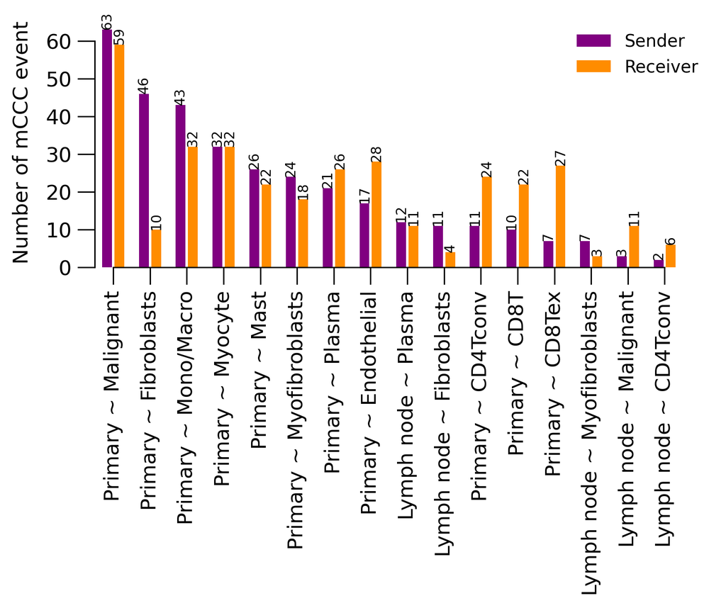

```python
## sender and receiver event number
mebo_obj.eventnum_bar(
                    sender_focus=[],
                    metabolite_focus=[],
                    sensor_focus=[],
                    receiver_focus=[],
                    ## uncomment and set to focus on one condition
                    # conditions = ['Primary'],
                    xorder=[],
                    and_or='and',
                    pval_method='permutation_test_fdr',
                    pval_cutoff=0.05,
                    comm_score_col='Commu_Score',
                    comm_score_cutoff = 0,
                    cutoff_prop = 0.25,
                    figsize=(6, 5),
                    save=None,
                    show_plot=True,
                    show_num = True,
                    include=['sender-receiver'],
                    group_by_cell=True,
                    colorcmap='tab20',
                    return_fig=False
                )
```

# 2. Differential Analysis

```python
## check condition names
print(mebo_obj.cell_ann[mebo_obj.condition_col].unique().tolist())
```

```
['Lymph node', 'Primary']
```

#### 2.1 Run diff mCCC analysis using mebo_obj.CommDiff() function

By default, it only evaluate differential status for mCCC in either one of the conditions, that was noted by sig_mccc_only = True. To turn off it, set to False. In addition to that, flux_pass = True indicate the algorithm considers only mCCC with efflux/influx rate passing the constaints to be significant mCCC. To turn off it, set flux_pass = False. Noted that flux_pass parameter is only effective when sig_mccc_only = True

```python
## set comparison, please connect two conditions with "_vs_" for a comparison
## if you have multiple conditions, it is allowed to expand the comparison list, e.g. ['cond1_vs_cond2', 'cond3_vs_cond3']

comp_cond = ['Primary_vs_Lymph node']

mebo_obj.CommDiff(
    comps=comp_cond,
    sig_mccc_only=True,
    flux_pass=True,
    thread=8)
```

```
[August 12, 2025 14:21:48]: Diff Comm for Primary_vs_Lymph node
[August 12, 2025 14:21:48]: Compute diff mCCC
[August 12, 2025 14:21:48]: Cond1 is Primary, Cond2 is Lymph node
[August 12, 2025 14:21:48]: Compute fold change
[August 12, 2025 14:21:51]: Estimate background diff
[August 12, 2025 14:23:07]: Test significance
[August 12, 2025 14:23:16]: Diff mCCC Analysis Done in 88.0245 seconds
[August 12, 2025 14:23:16]: Memory Usage in Peak 0.20 GB
```

### 2.2 Check differential mCCC table for a comparison

All differential results are stored in mebo_obj.diffcomm_res slot in a dict format with comparison as key and differential mCCC data frame as values.

```python
print('Differential result is ready for: ', list(mebo_obj.diffcomm_res.keys()))
```

```
Differential result is ready for:  ['Primary_vs_Lymph node']
```

```python
comp = 'Primary_vs_Lymph node'

diff_res = mebo_obj.diffcomm_res[comp].copy()

print('# of up-regulated mCCC: ', diff_res.query('permutation_test_fdr < 0.05 and Log2FC > 0').shape[0])
print('# of down-regulated mCCC: ', diff_res.query('permutation_test_fdr < 0.05 and Log2FC < 0').shape[0])
```

```
# of up-regulated mCCC:  69
# of down-regulated mCCC:  44
```

### 2.3 visualize differential mCCC results using a scatter plot

In this plot, the X and Y axis represent the communication score for two samples in the comparison. Dot size indicate different level of differences based on log2FC. The color labels significantly differential mCCC by considering FDR.

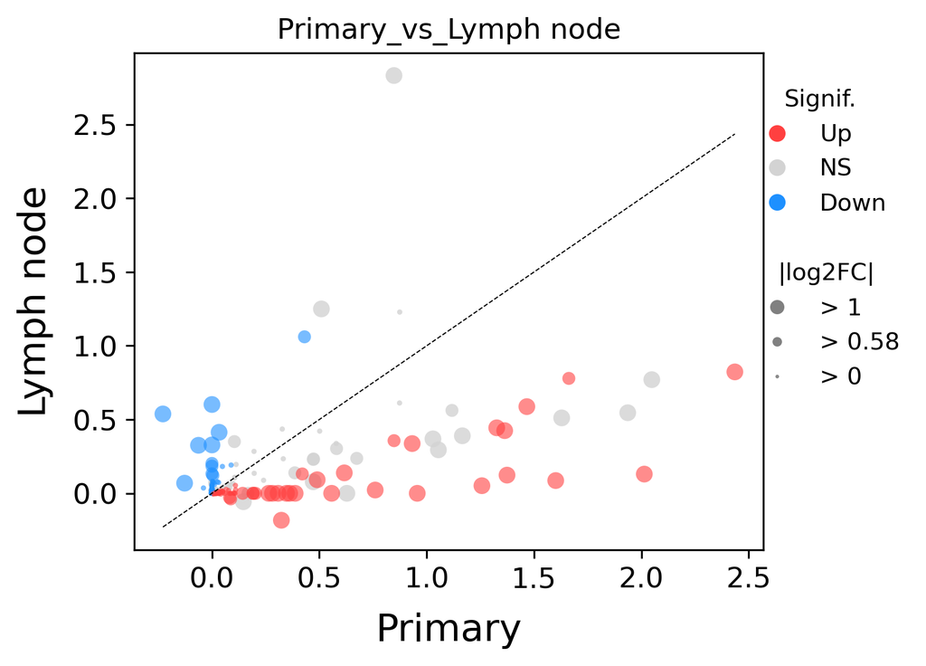

```python
mebo_obj.CompScatterPlot(
    comp_cond = 'Primary_vs_Lymph node',
    pval_method='permutation_test_fdr',
    pval_threshold=0.05,
    Log2FC_threshold=0,
    sender_focus=[],
    metabolite_focus=[],
    sensor_focus=[],
    receiver_focus=[],
    and_or='and',
    show_plot=True,
    figsize=(5.5, 4),
    return_fig=False,
    save=None)
```

### 2.4 visualize differential mCCC results using a differential flow plot

In this plot, the mCCC flow goes from sender, metabolite, sensor, to receiver cell types. The line color now represent the Log2FC of the comparision, which is different from the one sample analysis result visualizatio. We do not design linewidth to indicate anything.

```
[August 12, 2025 14:23:17]: plot flow plot to show the communications from Sender -> Metabolite -> Sensor -> Receiver
```

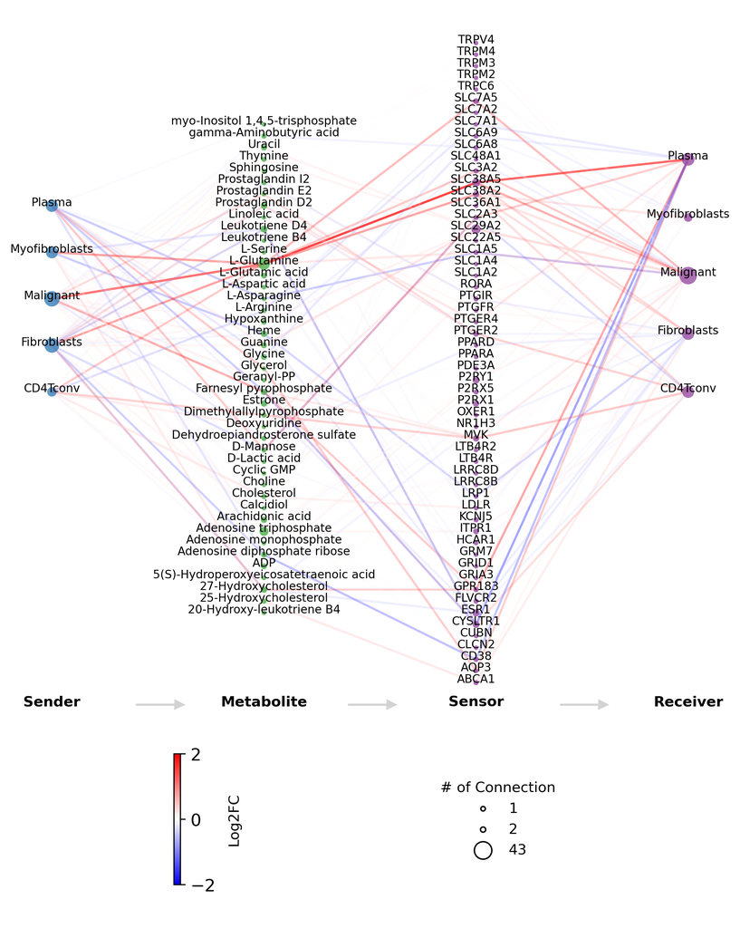

```python
mebo_obj.DiffFlowPlot(
                comp_cond = 'Primary_vs_Lymph node',
                pval_method='permutation_test_fdr',
                pval_cutoff=0.05,
                Log2FC_threshold=0,
                sender_focus = [],
                metabolite_focus = [],
                sensor_focus = [],
                receiver_focus = [],
                remove_unrelevant = True,
                and_or = 'and',
                node_label_size = 8,
                node_alpha = .8,
                figsize = 'auto',
                node_cmap = 'Set1',
                line_color_col = 'Log2FC',
                line_cmap = 'bwr',
                line_cmap_vmin = -2,
                line_cmap_vmax = 2,
                line_cmap_center = 0,
                linewidth = 1.5,
                node_size_norm = (10, 150),
                node_value_range = None,
                save=None,
                save_plot = False,
                show_plot = True,
                text_outline = False,
                return_fig = False)
```

### 2.3 Get a summary of top-ranked sender, receiver, and metabolites in differential mCCC results.

In this plot, we summarize how many differential mCCC events for each sender cell type, receiver cell type, and metabolites. The cell types and metabolites were shown if they were associated with the highest number of differential mCCC events.

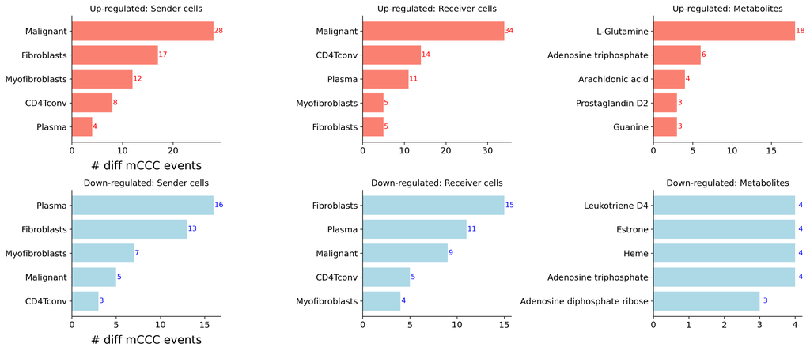

```python
mebo_obj.DiffSummaryPlot(comp_cond = "Primary_vs_Lymph node",
                        pval_method='permutation_test_fdr',
                        pval_cutoff=0.05,
                        Log2FC_threshold = 0,
                        sender_focus = [],
                        metabolite_focus = [],
                        sensor_focus = [],
                        receiver_focus = [],
                        and_or = 'and',
                        numtop_bar = 5,
                        save=None,
                        return_fig = False)
```

# 3. Run different sample separately, and want to combine for diffrential analysis

Please refer to **Demo_one_sample_mCCC_analysis** for the instructions of running each sample separately.

Assume that we have two samples run separately for Primary and Lymph Node.

Assume that the results were saved into two files, named demo_primary.pk and demo_lymphnode.pk

Be sure to change the file names based on your data.

```python
## 1. read them separately
primary_obj = mebocost.load_obj(path = 'demo_primary.pk')
lymphnode_obj = mebocost.load_obj(path = 'demo_lymphnode.pk')

## concat two samples into one mebo_obj
combined_obj = mebocost.concat_obj(
                        obj1 = primary_obj,
                        obj2 = lymphnode_obj,
                        cond1='Primary'
                        cond2='Lymph node'
                        )
```

Once the combined_obj was created, please refer to the section #2 for differential analysis.